# Golf Putting

```r
URL <- "http://www.stat.columbia.edu/~gelman/bda.course/data/golf.txt"

golf_data <- read.table(URL, skip = 2, header = TRUE) %>%
  mutate(prop = y/n) %>%
  mutate(lower = prop - sqrt(prop*(1 - prop) / n),
         upper = prop + sqrt(prop*(1 - prop) / n)
         )

g <- golf_data %>%
  ggplot(aes(x, prop, ymin = lower, ymax = upper)) +
  geom_pointrange(size = 0.2) +
  labs(y = "Probability of success",
       x = "Distance from hole (feet)")
```

See more about this example [here](http://www.stat.columbia.edu/~gelman/research/published/golf.pdf).

The following graph shows data on the proportion of successful golf putts as a function of distance from the hole. Unsurprisingly, the probability of making the shot declines as a function of distance:

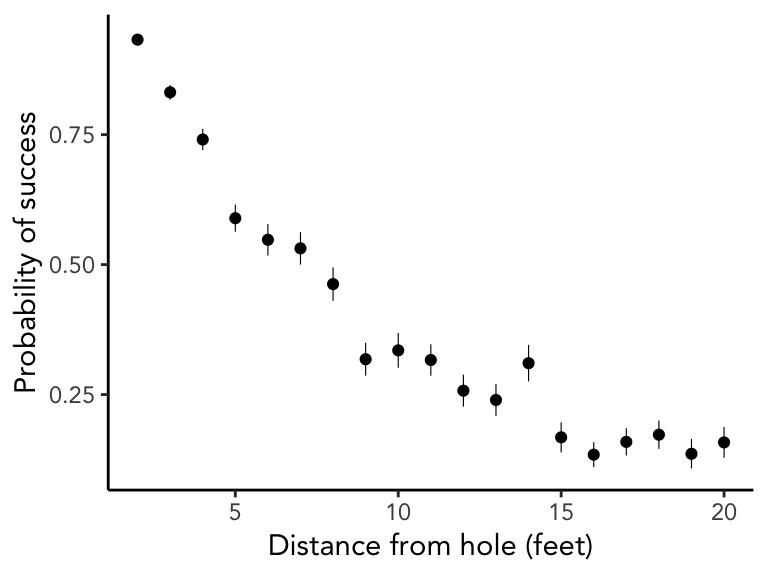

```r
g
```

How can we model the probability of success in golf putting as a function of distance from the hole? The usual statistical practice would indicate that we need to use a logistic regression:

$$\begin{align}
&p_j = \text{logit}^{-1}(a + bx_j) \\ \\
&y_j \sim \textsf{binomial}(n_j, p_j)
\end{align}$$

```r
readLines("programs/golf_logistic.stan") %>%
  writeLines()
```

```
data {
  int J;
  int n[J];         // note the that location of the [J]
  vector[J] dist;   // is different for "int" and "vector"
  int success[J];
}
parameters {
  real a;
  real b;
}
model {
  success ~ binomial_logit(n, a + b*dist);
}
```

```r
golf_data_list <- with(golf_data, list(
  dist = x,
  n = n,
  success = y,
  J = nrow(golf_data)
  ))

golf_logistic <- stan("programs/golf_logistic.stan",
     data = golf_data_list)
```

```r
print(golf_logistic, probs = c(0.025, 0.5, 0.975))
```

```
Inference for Stan model: golf_logistic.
4 chains, each with iter=2000; warmup=1000; thin=1;
post-warmup draws per chain=1000, total post-warmup draws=4000.

         mean se_mean   sd     2.5%      50%    97.5% n_eff Rhat
a        2.23    0.00 0.06     2.11     2.23     2.34   968    1
b       -0.26    0.00 0.01    -0.27    -0.26    -0.24  1028    1
lp__ -3021.13    0.03 0.96 -3023.78 -3020.83 -3020.18  1226    1

Samples were drawn using NUTS(diag_e) at Fri Mar  1 19:02:53 2019.
For each parameter, n_eff is a crude measure of effective sample size,
and Rhat is the potential scale reduction factor on split chains (at
convergence, Rhat=1).
```

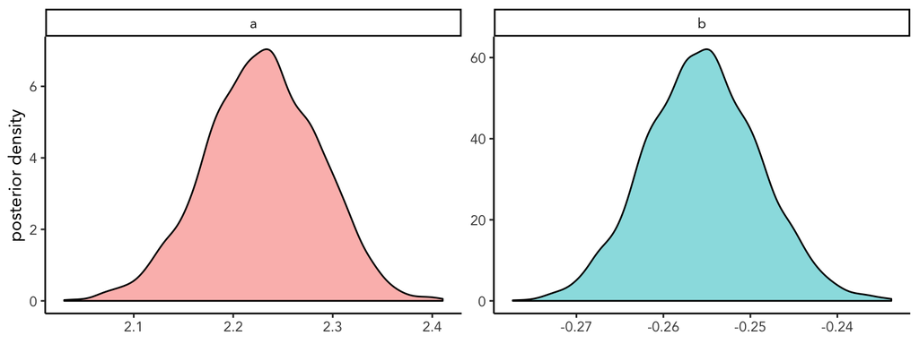

```r
posterior_logistic <- extract(golf_logistic)

df_logistic <- as_tibble(posterior_logistic) %>%
  gather(a, b, key = "parameter", value = "estimate")

df_logistic %>%
  ggplot(aes(x = estimate, fill = parameter)) +
  geom_density(show.legend = FALSE, alpha = 0.5) +
  facet_wrap(~parameter, ncol = 2, scales = "free") +
  labs(x = NULL, y = "posterior density")
```

Note that this model doesn’t actually fit the data really well. For starters, the probability of success isn’t predicted to be 1 when the distance is zero! This point isn’t sufficiently emphasized: with enough data, we can obtain very precise estimates from a wrong model.

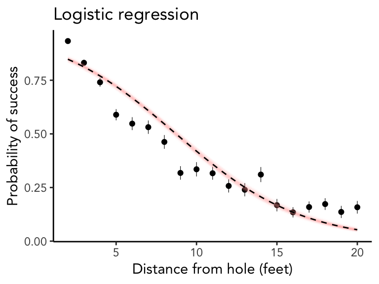

```r
invlogit <- function(a, b, x) {
  linpred <- a + b*x
  1 / (1 + exp(-linpred))
}

g_logistic <- g
for (i in sample(4000, 200)) {
  g_logistic <- g_logistic +
    stat_function(fun = invlogit,
                  args = list(
                    a = posterior_logistic$a[i],
                    b = posterior_logistic$b[i]),
                  alpha = 0.01, color = "pink")
}

g_logistic +
  stat_function(fun = invlogit,
                args = list(
                  a = mean(posterior_logistic$a),
                  b = mean(posterior_logistic$b)
                  ), linetype = "dashed") +
  labs(title = "Logistic regression")
```

**Modeling from first principles**

As an alternative to logistic regression, Gelman builds a model from first principles. The graph below shows a simplified sketch of a golf shot. The dotted line represents the angle within which the ball of radius $r$ must be hit so that it falls within the hole of radius $R$. This threshold angle is as follows:

$$\theta = \sin^{-1} \left(\frac{R-r}{x}\right)$$

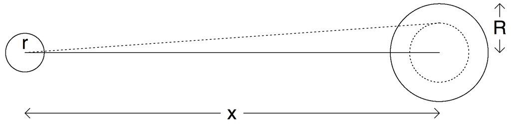

golf diagram

The next step is to model *human error*. The golfer is attempting to hit the ball completely straight but many small factors interfere with this goal, so that the actual angle follows a normal distribution centered at 0 with standard deviation $\sigma$.

The probability that the ball goes in the hole is then the probability that the angle is less than the threshold:

$$p_i = 2 \Phi \left(\frac{\theta_i}{\sigma}\right) - 1$$

where $\Phi$ is the Normal cumulative distribution function (centered at zero). Note that the angle $\theta$ is the *only* random variable in this model and that $\sigma$ is the only parameter that we actually need to estimate.

**Note**. This formula is equivalent to the following:

$$p_i = 1 - 2 \Phi \left(- \frac{\theta_i}{\sigma}\right)$$

*Why do we use a normal distribution?* Because we are aiming at zero and there are many contributing additive factors that skew the ball one way or the other. We could have also used a $t$-distribution, which is just a *mixture* of normal distributions with different variances (e.g. some players are better than others, some courses are easier, and so on).

```r
readLines("programs/golf_geometry.stan") %>%
  writeLines()
```

```
data {
  int J;
  real r;
  real R;
  int n[J];
  vector[J] dist;
  int success[J];
}
parameters {
  real<lower=0> sigma;
}
model {
  vector[J] p;
  for (j in 1:J){
    p[j] = 2*Phi(asin((R-r) / dist[j]) / sigma) - 1;
  }
  success ~ binomial(n, p);
}
```

```r
golf_data_list$r <- 1.68 / 12      ## 1.68 inches in feet
golf_data_list$R <- 4.25 / 12      ## 4.25 inches in feet

golf_geometry <- stan("programs/golf_geometry.stan",
     data = golf_data_list)
```

```r
print(golf_geometry, probs = c(0.025, 0.5, 0.975))
```

```
Inference for Stan model: golf_geometry.
4 chains, each with iter=2000; warmup=1000; thin=1;
post-warmup draws per chain=1000, total post-warmup draws=4000.

          mean se_mean   sd     2.5%      50%    97.5% n_eff Rhat
sigma     0.05    0.00 0.00     0.05     0.05     0.05  1116    1
lp__  -2926.27    0.02 0.71 -2928.29 -2926.01 -2925.76  1777    1

Samples were drawn using NUTS(diag_e) at Fri Mar  1 19:03:00 2019.
For each parameter, n_eff is a crude measure of effective sample size,
and Rhat is the potential scale reduction factor on split chains (at
convergence, Rhat=1).
```

```r
posterior_geometry <- extract(golf_geometry)

golf_link <- function(sigma, x) {
  r <- 1.68 / 12
  R <- 4.25 / 12
  return(2*pnorm((1/sigma) * asin((R - r) / x)) - 1)
}

g_golf <- g

for (i in sample(4000, 200)) {
  g_golf <- g_golf +
      stat_function(fun = golf_link,
                args = list(
                  sigma = posterior_geometry$sigma[i]),
                alpha = 0.01, color = "pink")
}

posterior_geometry$theta
```

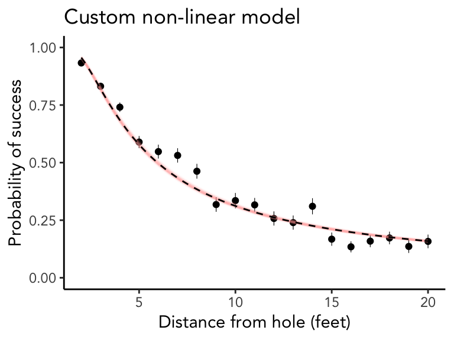

```r
g_golf +
  stat_function(fun = golf_link,
                args = list(
                  sigma = mean(posterior_geometry$sigma)),
                linetype = "dashed") +
  labs(title = "Custom non-linear model") +
  coord_cartesian(ylim = c(0, 1))
```